# Planejamento e Análise de Experimentos (EEE933) Estudo de Caso 1

Pedro Vinícius, Samara Silva e Savio Vieira

10 de Agosto de 2020

# Introdução

Uma versão atual de um software conhecido apresenta uma distribuição dos custos de execução com média populacional $\mu_c = 50$ e variância populacional $\sigma^2_c = 100$. Posteriormente, uma nova versão do software é desenvolvida, no qual deseja-se investigar prováveis melhorias de desempenho. Com esse intuito, duas análises estatísticas são propostas: (i) uma sobre o custo médio e (ii) uma sobre a variância do custo.

Para ambos os casos, as hipóteses nulas foram definidas de maneira conservadora, partindo-se do pressuposto de que os parâmetros populacionais conhecidos foram mantidos na nova versão. A partir disso, diversas etapas foram conduzidas até a conclusão dos experimentos, entre elas a coleta de dados da distribuição dos custos do software novo, a análise exploratória dessa amostra, a inferência por meio dos testes estatísticos, a validação das premissas consideradas e as conclusões. As próximas seções contém o detalhamento técnico de cada uma dessas etapas.

## Parte 1: Teste Sobre o Custo Médio

### Planejamento dos Experimentos

No que se refere a primeira parte do estudo de caso, o teste terá que dispor de um nível de significância $\alpha = 0,01$, um tamanho de efeito de mínima relevância $\delta^* = 4$ e uma potência desejada $\pi = 1 - \beta = 0,8$. As hipóteses estatísticas foram definidas com o intuito de responder às questões propostas abaixo:

- Há alguma diferença entre o custo médio da versão nova do software e o custo médio da versão corrente?
- Caso haja, qual a melhor versão em termos de custo médio?

Em concordância com a proposta de comparação de custo médio entre as versões, as hipóteses de teste podem ser formuladas sobre o parâmetro média:
$$\begin{cases} H_0: \mu_n = 50&\\H_1: \mu_n<50\end{cases}$$
onde a hipótese nula implica na igualdade entre os custos médios das versões e a hipótese alternativa unilateral na superioridade da nova versão em termos de custo médio.

A fase subsequente desse experimento consiste em gerar uma amostra representativa do desempenho da nova versão do software. Para tal fim, é necessário especificar o tamanho dessa amostra, considerando as propriedades preestabelecidas do teste. A priori, o Poder do Teste é bastante conveniente, porém implica em um grande dilema. O cálculo do tamanho amostral requer uma estimativa da variância, que só é obtida através das observações contidas na amostra. As possibilidades mais práticas de se conduzir o experimento nesse caso são :

1. Utilização de conhecimento do problema para se obter uma estimativa (inicial) da variância;
2. Condução do estudo com um tamanho amostral predefinido, como $N = 30$;
3. Realização de um estudo piloto para estimar a variância dos dados a partir do tamanho de efeito de mínima relevância $\delta^*$.

Considerando as vantagens e desvantagens de cada uma, optou-se por utilizar a primeira abordagem. Por mais que essa estimativa seja sobre-estimada e que os prováveis ganhos possam não ser observados ao término do estudo, uma vez que se espera ganhos de variância da nova versão do software em relação à versão atual, pode-se considerar igualdade de variâncias como uma estimativa inicial, ou seja, $\sigma^2_n \approx \sigma^2_c = 100$. Entretanto, essa premissa será avaliada posteriormente na análise exploratória dos dados e na discussão sobre a potência alcançada.

Diante da estimativa inicial da variância amostral, o Poder do Teste pode ser finalmente realizado. Esse teste é originalmente usado para mensurar o controle do teste de hipóteses sobre o erro do tipo II ($\beta$), isto é, $P(\mbox{rejeitar}\ H_0|H_0 \ \mbox{é falso})$. No entanto, tal teste também pode ser utilizado para estimar outros parâmetros amostrais, como tamanho de efeito $\delta^*$, nível de significância $\alpha$, tamanho da amostra $N$, potência $\pi$ e desvio padrão amostral $\sigma_n$ . No presente estudo, ele é utilizado para estimar o tamanho amostral $N$.

```r
# Poder do Teste para estimar o tamanho amostral
(params <- power.t.test(delta = 4,
             sd = 10,
             sig.level = 0.01,
             power = 0.8,
             type = "one.sample",
             alternative = "one.sided"))
```

```
##
##      One-sample t test power calculation
##
##               n = 65.45847
##           delta = 4
##              sd = 10
##       sig.level = 0.01
##           power = 0.8
##     alternative = one.sided
```

```r
N <- ceiling(params$n)
```

Assim, tem-se uma estimativa de $N = 66$ observações com o arredondamento superior.

### Coleta dos Dados

O custo de execução do software novo é modelado por um algoritmo de Evolução Diferencial que faz uso de recombinação binomial, mutação aleatória e seleção elitista padrão para a minimização do *Shifted Sphere Problem*. Dessa forma, como cada observação é obtida por meio do módulo `ExpDE` em linguagem R , foram necessárias $N$ execuções para construção da amostra. Os dados coletados foram salvos em um arquivo `.csv` com uma semente definida empiricamente `seed = 1007`. Uma vez que a amostra está fixa, as análises estatísticas da média e da variância poderão ser efetuadas sobre os mesmos dados.

```r
data_generation <- function(n){

  mre <- list(name = "recombination_bin", cr = 0.9)
  mmu <- list(name = "mutation_rand", f = 2)
  mpo <- 100
  mse <- list(name = "selection_standard")
  mst <- list(names = "stop_maxeval", maxevals = 10000)
  mpr <- list(name = "sphere", xmin = -seq(1, 20), xmax = 20 + 5 * seq(5, 24))

  sample <- c()
  # Geração de N observações
  for (i in 1:n){
    observation <- ExpDE(mpo, mmu, mre, mse, mst, mpr,
                    showpars = list(show.iters = "none"))$Fbest
    sample <- c(sample, observation)
  }
  return(sample)
}
```

### Análise Exploratória de Dados

Algumas primeiras propriedades da amostra, como média, mediana, valores extremos e variância, podem ser obtidas de imediato.

```r
data.frame('Variância' = var(sample), 'Média' = mean(sample), 'Moda' = getmode(sample),
                                'Mediana' = median(sample), 'Mínimo' = min(sample),
                                'Máximo' = max(sample), 'Desvio' = sd(sample))
```

| Variância | Média | Moda | Mediana | Mínimo | Máximo | Desvio |
| --- | --- | --- | --- | --- | --- | --- |
| 36.6344 | 49.63844 | 48.79741 | 48.92703 | 38.76112 | 67.21031 | 6.052636 |

É importante ressaltar que a variância é significativamente menor que a considerada no cálculo do tamanho amostral $N$, assim, caso as premissas consideradas sejam válidas, a potência do teste será superior a desejada ($\pi > 0,8$).

Entretanto, a fim de compreender melhor os dados em estudo, algumas representações gráficas da amostra coletada serão investigadas. Inicialmente, faz-se o uso do histograma, que representa a distribuição de frequências das observações. O histograma é uma boa ferramenta de análise visual do comportamento de variáveis contínuas em geral, auxiliando no processo de visualização de características, como a média da amostra e a variação da distribuição em torno da mesma. Para a amostra em questão, o histograma mostra uma distribuição levemente inclinada à direita, que corrobora que a média é maior do que a moda, bem como sugere a presença de outliers com custos maiores que 60 (Figura ).

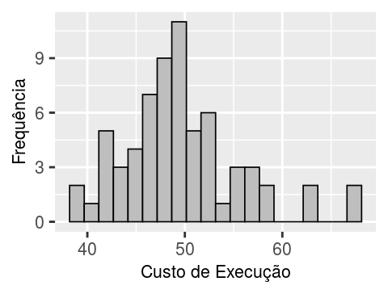

Histograma.

```r
histogram <- ggplot(data = as.data.frame(sample), mapping = aes(x = sample))
histogram + geom_histogram(lwd = 0.3, bins = 20, color = 'black', fill = 'gray') +
            scale_x_continuous(name = 'Custo de Execução') +
            scale_y_continuous(name = 'Frequência')
```

Posteriormente, o boxplot, também conhecido como gráfico de caixa, é considerado. Além de descrever simultaneamente várias propriedades importantes de um conjunto de dados, como centro, dispersão e desvio de simetria, ele também possiblita a identificação de valores atípicos . Para a amostra em questão, foi possível reforçar a presença das observações em torno da mediana levemente inferior a 50 (segundo quartil). Outro aspecto importante é a presença de uma assimetria positiva na distribuição, uma vez que a mediana está mais próxima do primeiro do que do terceiro quartil. A diferença nos comprimentos das linhas que saem da caixa pressupõe novamente a cauda acentuada à direita (Figura ).

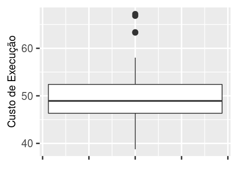

Boxplot.

```r
boxplot <- ggplot(data = as.data.frame(sample), mapping = aes(y = sample))
boxplot + geom_boxplot(lwd = 0.3) + scale_x_continuous(name = '') +
          scale_y_continuous(name = 'Custo de Execução') +
          theme(axis.text.x = element_blank())
```

Por fim, um gráfico bastante utilizado em estatística é o quantil-quantil (*QQ-Plot*), cujo objetivo é verificar a adequação da distribuição de frequência dos dados à uma distribuição de probabilidades de interesse. Caso os dados tenham distribuições idênticas, uma linha reta com inclinação unitária é traçada. A densidade com que os pontos são representados indicam a frequência de ocorrência dos mesmos . No presente trabalho, o gráfico Q-Q foi utilizado para comparar a distribuição dos custos de execução da nova versão do software com uma distribuição normal. Ao gerá-lo, é evidente que os dados não seguem um padrão linear e, portanto, não provém de uma distribuição normal (Figura ).

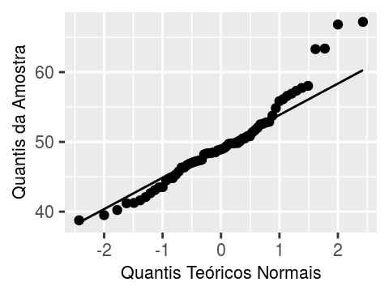

QQ-Plot.

```r
qqplot <- ggplot(data = as.data.frame(sample), mapping = aes(sample = sample))
qqplot + geom_qq_line() + geom_qq() + scale_y_continuous(name = 'Quantis da Amostra') +
         scale_x_continuous(name = 'Quantis Teóricos Normais')
```

### Validação de Premissas

Devido à presumível falta de normalidade dos dados, o teste de Shapiro-Wilk foi feito para confirmação. A hipótese nula $H_0$ desse teste assume que a amostra veio de uma população com distribuição normal e para isso o parâmetro $W$ é calculado e comparado com um valor de referência. Caso a resultante de $W$ seja inferior ao valor tabelado, rejeita-se a hipótese de normalidade a um nível de significância $\alpha$ . A aplicação do teste gerou como resultado $W = 0,94772$ e o valor de $p = 0,00755$, que confirmam a não normalidade dos dados ($p < 0,05$).

```r
(shapiro_test <- shapiro.test(x = sort(sample)))
```

```
##
##  Shapiro-Wilk normality test
##
## data:  sort(sample)
## W = 0.94772, p-value = 0.007555
```

Apesar disso, como o número de observações é suficientemente grande ($N=66 >\!\!> 30$), o Teorema do Limite Central (TLC) pôde ser evocado para estimação da distribuição amostral das médias. Já a premissa de independência foi assumida no processo de coleta dos dados. Caso uma amostra do software atual estivesse disponível, o teste de Durbin-Watson também caberia para avaliar uma possível autocorrelação nos resíduos.

### Análise Estatística

A partir disso, pode-se realizar o Teste t de Student sem que suas premissas sejam violadas.

```r
(t_test <- t.test(x = sample,
                mu = 50,
                alternative = "less",
                conf.level = 0.99))
```

```
##
##  One Sample t-test
##
## data:  sample
## t = -0.4853, df = 65, p-value = 0.3145
## alternative hypothesis: true mean is less than 50
## 99 percent confidence interval:
##     -Inf 51.4154
## sample estimates:
## mean of x
##  49.63844
```

```r
cat('Intervalo de confiança:', t_test$conf.int[1:2])
```

```
## Intervalo de confiança: -Inf 51.4154
```

### Potência do Teste

Conforme relatado anteriormente, como a estimativa da variância amostral foi substancialmente superior à variância calculada sobre os dados, é bem provável que a potência do teste seja superior aos $80\%$ utilizados para o cálculo do tamanho amostral $N$. Dessa forma, uma estimativa da potência para detecção de diferenças maiores ou iguais ao tamanho de efeito $\delta^*$ pode ser obtida pelo Poder do Teste, utilizando o desvio padrão amostral $\sigma = 6,0526$, o tamanho amostral $N=66$ e conservando as demais propriedades.

```r
(params <- power.t.test(delta = 4,
             sd = sqrt(var(sample)),
             sig.level = 0.01,
             n = 66,
             type = "one.sample",
             alternative = "one.sided"))
```

```
##
##      One-sample t test power calculation
##
##               n = 66
##           delta = 4
##              sd = 6.052636
##       sig.level = 0.01
##           power = 0.9982989
##     alternative = one.sided
```

```r
cat('Potência obtida:', params$power)
```

```
## Potência obtida: 0.9982989
```

Em concordância com o que se esperava, a potência obtida $\pi = 0,9982$ é superior à desejada.

Outra perspectiva para esse caso é que, consequentemente, o número de observações na amostra foi sobre-estimado. Assim, uma estimativa para $N$ capaz de garantir exatamente a potência desejada $\pi = 0,8$ pode ser obtida pelo Poder de Teste ao utilizar o desvio padrão amostral em conjunto com os demais parâmetros.

```r
(params <- power.t.test(delta = 4,
             sd = sqrt(var(sample)),
             sig.level = 0.01,
             power = 0.8,
             type = "one.sample",
             alternative = "one.sided"))
```

```
##
##      One-sample t test power calculation
##
##               n = 25.752
##           delta = 4
##              sd = 6.052636
##       sig.level = 0.01
##           power = 0.8
##     alternative = one.sided
```

```r
cat('Tamanho amostral:', ceiling(params$n))
```

```
## Tamanho amostral: 26
```

Ou seja, o tamanho amostral necessário para o experimento é de apenas 26 observações, 40 observações a menos do que foi utilizado na estimativa inicial.

## Parte 2: Teste Sobre a Variância do Custo

## Planejamento dos Experimentos

Em relação à segunda parte deste experimento, as hipóteses estatísticas foram definidas com o intuito de responder às questões propostas abaixo:

- Há alguma diferença entre a variância do custo de execução da versão nova do software e a variância do custo de execução da versão corrente?
- Caso haja, qual a melhor versão em termos de variância do custo?

$$\begin{cases} H_0: \sigma^2_n = 100&\\H_1: \sigma^2_n<100\end{cases}$$
onde a hipótese nula $H_0$ representa a equivalência das variâncias entre as duas versões e a hipótese alternativa $H_1$ a redução da variância do custo do software nessa nova versão em análise.

### Tentativas Iniciais

Existem vários testes estatísticos para comparação de variância, como o teste F, o teste de Bonett, o teste Chi-quadrado, o teste de Levene, dentre outros. Todavia, além das particularidades de cada um deles, os três primeiros são indicados para distribuições normais. Além disso, tendo em vista que o TLC não é aplicável para o estimador amostral da variância, uma das opções recomendadas é o uso de um teste não-paramétrico, como o teste de Levene.

O Teste de Levene tem como hipótese nula a proposição de que os grupos que estão sendo comparados têm variâncias iguais, enquanto que a hipótese alternativa é que pelo menos um par desses grupos não possui igualdade de variância. Entretanto, essa categorização não comporta a situação em questão, visto que o intuito é a comparação da amostra da versão nova com o valor de referência da versão atual. Nesse âmbito, um teste não-paramétrico apropriado deve receber somente uma amostra para compará-la com uma variância populacional conhecida, o que, portanto, descarta o teste de Levene para o problema em questão.

Em virtude disso, bem como da escassez de métodos não-paramétricos compatíveis aos dados, outras abordagens foram investigadas. A primeira delas trata-se de uma transformação nos dados com o intuito de torná-los normais. As transformações monotônicas não-lineares $\log_{10}$ e quadrática mudam a distância entre os valores na distribuição e, portanto, a forma da distribuição . A primeira calcula o logaritmo na base 10 de um grupo de números contidos na calda à direita da distribuição para reduzir a inclinação positiva, enquanto a segunda toma a raiz quadrada de grandes valores, levando os valores altos para mais próximo do centro. Contudo, as tentativas de transformações não asseguraram normalidade aos dados.

### Solução Proposta

Por fim, a possibilidade encontrada para testar as hipóteses de teste foi a reamostragem dos dados. Essa técnica consiste em descartar a distribuição amostral assumida de uma estatística e calcular uma distribuição empírica à sua real distribuição. Assim, uma vez que essa distribuição é estimada, testes estatísticos podem ser realizados, intervalos de confiança podem ser construídos e hipóteses podem ser testadas sem que seja necessário validar premissas inerentes à distribuição .

Dentre os métodos da literatura mais comuns estão *Jackknife* e *Bootstrap* . Ambas as técnicas são bastante utilizadas para avaliar a variância de um estimador a partir da sua distribuição empírica. No entanto, o *Jackknife* é mais conservador e, consequentemente, produz erros padrões maiores . Em vista disso, optou-se pelo uso da técnica de *Bootstrap* do tipo não-paramétrico para estimar a distribuição da variância amostral do software novo, cuja região coberta pelo intervalo de confiança permitirá testar a hipótese de interesse ao nível de significância previamente definido em $\alpha=0,05$.

A partir do módulo `boot` em linguagem R , que contempla funções e conjuntos de dados para reamostragem do livro *Bootstrap Methods and Their Application* , foi possível realizar o experimento proposto. Uma estimativa ideal da distribuição empírica por reamostragem *Bootstrap* leva o número de replicações ao infinito e, em regras gerais, utiliza-se um número relativamente grande ($R > 1.000$) . Como o processo do presente estudo não demanda muito esforço computacional, o número de replicações para estimar a distribuição amostral da função estatística variância foi definido em $R=10.000$, de forma a minimizar o erro de amortecimento intrínseco ao *Bootstrap* devido à reamostragem finita. Por fim, é possível encontrar o intervalo de confiança correspondente à distribuição estimada. A função `boot.ci` permite gerar cinco tipos diferentes de intervalo de confiança não-paramétricos e bilaterais: (i) *basic*, (ii) *studentized*, (iii) *percentile*, (iv) *adjusted percentile* (BCa) e (v) *first order normal approximation* .

A priori, o tipo de intervalo definido foi o BCa, uma vez que ele é um intervalo mais preciso (segunda ordem) e permite ajustar distorções na distribuição, como viés e assimetria. Se a distribuição empírica foi distorcida positivamente, o intervalo de confiança é ajustado para a direita. Caso a distribuição seja distorcida negativamente, o intervalo é ajustado para a esquerda .

Conforme especificado anteriormente, deseja-se ainda um nível de confiança de $95\%$, entretanto, a estimativa do intervalo de confiança obtida pelo `boot.ci` é bilateral. Uma potencial alternativa para esse caso é ajustar o nível de confiança para $90\%$, de tal forma que cada lado do intervalo tenha a probabilidade de erro do tipo I desejada $\alpha=0,05$ .

Supondo novamente que os dados são independentes e identicamente distribuídos em razão do seu processo de coleta e que a reamostragem já foi calculada com $R$ suficientemente grande, é possível estimar o intervalo de confiança para o estimador variância amostral. A reprodutibilidade do experimento é possível a partir da semente aleatória fixa em `seed = 1007`.

```r
# Função estatística
statistic_function <- function(x, i){
  variance <- var(x[i])
  return(variance)
}

# Semente aleatória
set.seed(1007)

# Bootstrap com 10000 replicações
resampling <- boot(data = sample, statistic = statistic_function, R = 10000)

# Intervalo de confiança não-paramétrico
boot.ci(boot.out = resampling, conf = 0.90, type = 'bca')
```

```
## BOOTSTRAP CONFIDENCE INTERVAL CALCULATIONS
## Based on 10000 bootstrap replicates
##
## CALL :
## boot.ci(boot.out = resampling, conf = 0.9, type = "bca")
##
## Intervals :
## Level       BCa
## 90%   (26.21, 53.07 )
## Calculations and Intervals on Original Scale
```

É possível afirmar, ao nível de confiança de $95\%$, que a variância da nova versão do software é substancialmente inferior à variância da versão atual ($53,07 <\!\!< 100)$. Com o intuito de corroborar a ausência de influência do tipo de intervalo de confiança definido previamente no resultado, o teste foi feito para os demais tipos e pode-se concluir que em todos os casos há evidências estatísticas de que a versão nova é melhor que a versão atual em termos da variância do custo de execução.

## Questão Bônus

```r
# Questão Bônus
out <- nptol.int(sort(sample), alpha = 0.05, P = 0.90, side = 2, method = "WILKS",
                 upper = NULL, lower = NULL)
show(out)
```

```
##   alpha   P 2-sided.lower 2-sided.upper
## 1  0.05 0.9      38.76112      67.21031
```

Sendo assim, pode-se afirmar com $95\%$ de confiança de que $90\%$ dos dados estão contidos entre 38,76112 e 67,21031. As representações gráficas permitem uma melhor visualização do intervalo.

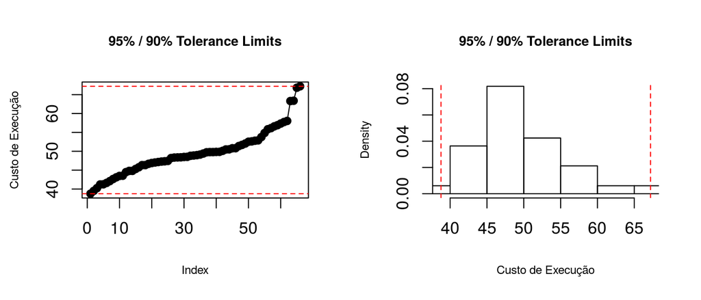

Intervalo de tolerância.

```r
par(cex.main = 0.8, cex.lab = 0.7, mfrow = c(1,2))
# Histograma
plottol(out, sort(sample), plot.type = "control", side = "two", x.lab = "Custo de Execução")
# Controle de Regressão
plottol(out, sort(sample), plot.type = "hist", side = "two", x.lab = "Custo de Execução")
```

## Conclusões

Com o objetivo de investigar sobre a possível melhora de desempenho de um software a partir de sua nova versão, comparando-a com a versão atual, foram utilizados conceitos e ferramentas estatísticas para inferir sobre o custo médio de execução e sobre a variância no custo de execução.

Sobre o custo médio de execução, conclui-se que por não ter sido rejeitada a hipótese nula de que o custo médio de execução é igual a $50$, neste caso, não pode-se inferir sobre a melhoria da nova versão sobre a versão atual. Vale lembrar que não rejeitar a hipótese nula não significa que ela é verdadeira, e sim que pelos testes realizados, com $99\%$ de confiança, não foi possível refutá-la. Porém, sobre a variância do custo da execução, a hipótese nula de que a variância é igual a $100$ foi rejeitada, neste caso, com os testes realizados, com $95\%$ de confiança, a hipótese alternativa foi aceita. Assim, a partir da análise realizada, conclui-se que, por esse quesito, houve melhoria da nova versão do software com relação a versão atual.

Diante das inferências apresentadas, recomenda-se a utilização da nova versão do software em substituição da versão atual.

### Discussão de Melhorias

Alguns testes não puderam ser feitos devido a não-normalidade da amostra obtida. Já outros testes pelo fato de se ter somente uma única amostra. Assim, uma vez que a versão atual é conhecida baseada em uma extensa experiência passada, como relata o enunciado do estudo de caso, sugere-se possibilidade de extrair uma amostra da versão atual do software. De posse desta amostra seria possível efetuar outros testes para calcular os estimadores de interesse, como o teste de Levene, e na tentativa até de se evitar a estimativa por reamostragem, conforme experimentado anteriormente.

### Atividades Desempenhadas

As hipóteses de teste para ambos experimentos foram definidas em concordância com os três autores. Em relação à primeira parte do estudo de caso, o cálculo do tamanho amostral e a coleta dos dados foram conduzidas pelo Pedro e discutidas com os demais autores. A análise exploratória teve participação de toda a equipe e a validação das premissas foi realizada pela Samara. Tanto a análise estatística quanto a discussão a posteriori da potência do teste e do tamanho amostral foram feitas pelo Pedro. A segunda parte do estudo caso, por sua vez, teve diversas discussões entre os membros até uma conclusão final. A Samara e o Sávio investigaram testes estatísticos de uma única amostra que não requisitassem a premissa de normalidade. Além disso, a Samara averiguou transformações não-lineares nos dados com o intuito de torná-los normais. Por fim, o Pedro implementou a reamostragem pela técnica *Bootstrap*, bem como analisou as premissas demandadas pelo tipo de intervalo de confiança não-paramétrico definido (BCa). A questão bônus e suas respectivas análises foram elaboradas pelo Sávio e pela Samara. Sávio ainda elaborou as conclusões e discussões de melhorias.